# Expression analysis for FBXO11 knockdown RNA-seq data

Jennifer Grants

1/9/2019

## Load saved data

`expr` is mRNA-seq TPM values, `libs` is metadata

```r
load("./FBXO11/expr.RData")
load("./FBXO11/libs.RData")
```

```r
libs$treatment <- ifelse(test = grepl(pattern = "shSCR", x = libs$specimen_subset_external_id), yes = "shSCR", no =
                           ifelse(test = grepl(pattern = "shFBXO11#9", x = libs$specimen_subset_external_id), yes = "shFBXO11.a", no = "shFBXO11.b"))
```

```r
kable(libs)
```

| library_name | sequencing_effort | platform_name | platform_version | specimen_subset_external_id | cohort_no | library_qc_info | index_sequence | treatment |
| --- | --- | --- | --- | --- | --- | --- | --- | --- |
| A54939 | Karsan Lab Research | ssRNA-Seq | v1 | OCI-AML3_shSCR-1 | Cohort 6 | {} | CCAACA | shSCR |
| A54940 | Karsan Lab Research | ssRNA-Seq | v1 | OCI-AML3_shFBXO11#9-1 | Cohort 6 | {} | CTAGCT | shFBXO11.a |
| A54941 | Karsan Lab Research | ssRNA-Seq | v1 | OCI-AML3_shFBXO11#10-1 | Cohort 6 | {} | GATGCT | shFBXO11.b |
| A54942 | Karsan Lab Research | ssRNA-Seq | v1 | OCI-AML3_shSCR-2 | Cohort 6 | {} | TAATCG | shSCR |
| A54943 | Karsan Lab Research | ssRNA-Seq | v1 | OCI-AML3_shFBXO11#9-2 | Cohort 6 | {} | TGAATG | shFBXO11.a |
| A54944 | Karsan Lab Research | ssRNA-Seq | v1 | OCI-AML3_shFBXO11#10-2 | Cohort 6 | {} | AGTTCC | shFBXO11.b |
| A54945 | Karsan Lab Research | ssRNA-Seq | v1 | OCI-AML3_shSCR-3 | Cohort 6 | {} | CGATGT | shSCR |
| A54946 | Karsan Lab Research | ssRNA-Seq | v1 | OCI-AML3_shFBXO11#9-3 | Cohort 6 | {} | TAGCTT | shFBXO11.a |
| A54947 | Karsan Lab Research | ssRNA-Seq | v1 | OCI-AML3_shFBXO11#10-3 | Cohort 6 | {} | AACTTG | shFBXO11.b |

# Quality control checks

### First convert row names from column “Names”:

```r
expr2 <- column_to_rownames(expr, var = "Name")
head(expr2)
```

```
## # A tibble: 6 x 9
##   A54945 A54947 A54946 A54944 A54940 A54942 A54941 A54939 A54943
##    <dbl>  <dbl>  <dbl>  <dbl>  <dbl>  <dbl>  <dbl>  <dbl>  <dbl>
## 1  0.176  0.561  0.102  0.459  0.115  0.307  0.274 0.381   0.180
## 2  0.609  0.235  0.170  0      0.141  0.267  0.514 0.0454  0
## 3  3.94   4.44   4.94   4.64   3.26   2.98   3.09  4.44    2.96
## 4  0      0      0      0      0      0      0     0       0
## 5  0      0      0      0      0      0      0     0       0
## 6  0      0      0      0      0      0      0     0       0
```

### Dimensions:

```r
# expression data
dim(expr2)
```

```
## [1] 195480      9
```

```r
# metadata
dim(libs)
```

```
## [1] 9 9
```

### NA values:

```r
any(is.na(expr2))
```

```
## [1] FALSE
```

### Range:

```r
range(expr2)
```

```
## [1]     0.00 39567.71
```

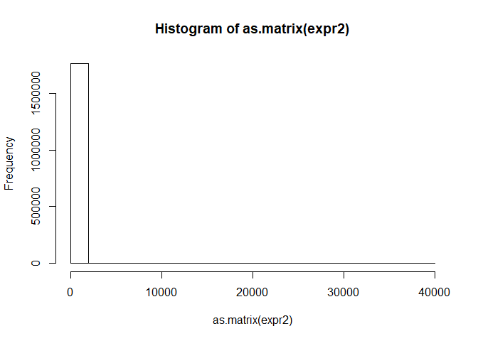

```r
hist(as.matrix(expr2))
```

Appears not to be log transformed.

## Data transformation / row normalization

### Log2 transformation

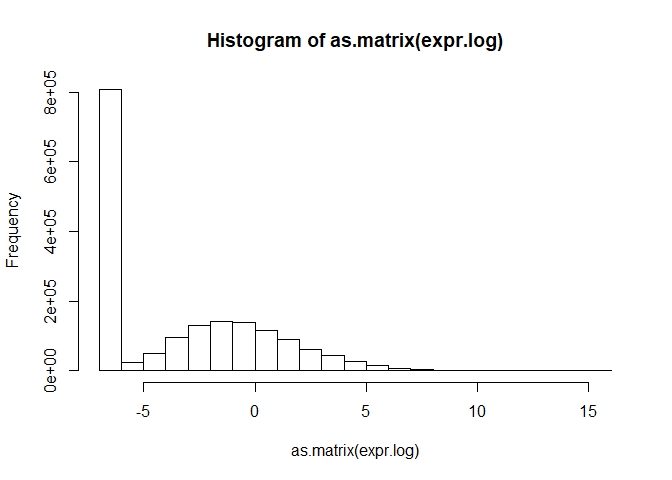

```r
# log2 transformation with constant +0.01 added to allow transformation of zeros
expr.log <- log2(expr2 + 0.01)

# Visualize log transformed data
hist(as.matrix(expr.log))
```

* ASK: Why does this have so many 0 values? Is this normal for RNA-seq? * Possible answer: Blood cells may not express that many genes highly… * LOOK UP: Griffith lab RNAseq data analysis tutorial online – assumptions

# DE-seq

> NOTE: Limma analysis appears to have more power for detecting relevant gene expression changes, probably because it better estimates the variance and because it is possible to model 3 conditions to avoid losing power

> Skip to Limma section!!

```r
design.table <- select(libs, library_name, treatment) %>%
  column_to_rownames(var = "library_name")
expr.matrix <- column_to_rownames(expr, var = "Name") %>%
  select(rownames(design.table)) %>% # put columns in same order as the design matrix
  as.matrix()
# filter to "highly expressed" genes
thresh <- expr.matrix >= 1
keep <- rowSums(thresh) >= 2 # keep rows where there are > 2 samples with tpm > 1

expr.matrix.keep <- expr.matrix[keep,]

# convert to integers for DEseq
int.matrix.keep <- round(expr.matrix.keep, digits = 0)

dds <- DESeqDataSetFromMatrix(countData = int.matrix.keep, colData = design.table, design = ~treatment)
res <- DESeq(dds)
```

## Summarise results by each treatment group

### shFBXO11.a vs. shSCR

```r
resultsNames(res)
```

```
## [1] "Intercept"
## [2] "treatment_shFBXO11.b_vs_shFBXO11.a"
## [3] "treatment_shSCR_vs_shFBXO11.a"
```

```r
result.pair <- results(res, contrast = c("treatment", "shFBXO11.a", "shSCR")) # contrast: the factor, then numerator, then denominator

kable(head(result.pair[which(result.pair$padj < 0.05),]))
```

|  | baseMean | log2FoldChange | lfcSE | stat | pvalue | padj |
| --- | --- | --- | --- | --- | --- | --- |
| ENST00000373449 | 98.18959 | -0.6872024 | 0.1931158 | -3.558499 | 0.0003730 | 0.0164194 |
| ENST00000396651 | 1376.61361 | -0.3319752 | 0.0656212 | -5.058962 | 0.0000004 | 0.0000518 |
| ENST00000370321 | 1253.92354 | -0.3414709 | 0.0754813 | -4.523914 | 0.0000061 | 0.0005594 |
| ENST00000369642 | 79.15805 | 1.2160224 | 0.2887543 | 4.211271 | 0.0000254 | 0.0017828 |
| ENST00000369637 | 84.30236 | 0.9893354 | 0.2674085 | 3.699716 | 0.0002158 | 0.0109731 |
| ENST00000607355 | 52.60446 | 1.9217321 | 0.3069893 | 6.259932 | 0.0000000 | 0.0000001 |

```r
write.csv(x = result.pair, file = "./FBXO11/DEseq/shFBXO11a_vs_shSCR.csv")
```

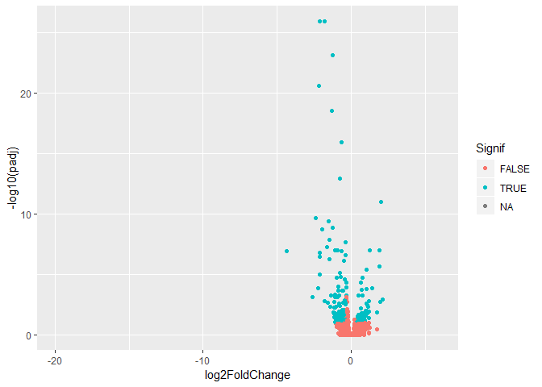

```r
# cutoffs: padj < 0.1, |FC| > 1.25 (permissive)
dat.a <- read.csv("./FBXO11/DEseq/shFBXO11a_vs_shSCR.csv") %>%
  mutate(Signif_p = -log10(padj) > -log10(0.1),
         Signif_delta = abs(log2FoldChange) > log2(1.25),
         Signif = Signif_p == TRUE & Signif_delta == TRUE)

ggplot(dat.a, aes(log2FoldChange, -log10(padj))) +
  geom_point(aes(colour = Signif))
```

### shFBXO11.b vs shSCR

```r
result.pair <- results(res, contrast = c("treatment", "shFBXO11.b", "shSCR")) # contrast: the factor, then numerator, then denominator

kable(head(result.pair[which(result.pair$padj < 0.05),]))
```

|  | baseMean | log2FoldChange | lfcSE | stat | pvalue | padj |
| --- | --- | --- | --- | --- | --- | --- |
| ENST00000344843 | 185.20045 | -1.4340034 | 0.1559497 | -9.195293 | 0.00e+00 | 0.0000000 |
| ENST00000376957 | 536.58206 | -0.4561490 | 0.1008886 | -4.521314 | 6.10e-06 | 0.0113374 |
| ENST00000329421 | 92.97947 | -0.9143182 | 0.1966855 | -4.648630 | 3.30e-06 | 0.0072363 |
| ENST00000582401 | 89.83154 | 0.8797400 | 0.1980195 | 4.442693 | 8.90e-06 | 0.0152587 |
| ENST00000480760 | 48.09922 | 1.0812659 | 0.2606061 | 4.149043 | 3.34e-05 | 0.0417657 |
| ENST00000367600 | 167.39928 | 0.8321301 | 0.1996213 | 4.168544 | 3.07e-05 | 0.0412676 |

```r
write.csv(x = result.pair, file = "./FBXO11/DEseq/shFBXO11b_vs_shSCR.csv")
```

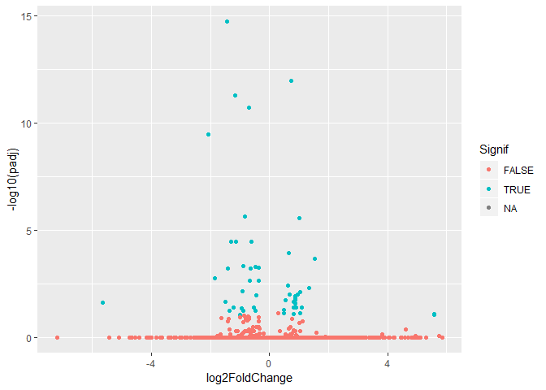

```r
# cutoffs: padj < 0.1, |FC| > 1.25 (permissive)
dat.b <- read.csv("./FBXO11/DEseq/shFBXO11b_vs_shSCR.csv") %>%
  mutate(Signif_p = -log10(padj) > -log10(0.1),
         Signif_delta = abs(log2FoldChange) > log2(1.25),
         Signif = Signif_p == TRUE & Signif_delta == TRUE)

ggplot(dat.b, aes(log2FoldChange, -log10(padj))) +
  geom_point(aes(colour = Signif))
```

## Heatmap for differentially expressed genes in either shFBXO11 treatment

```r
# filter to genes that are "signif" in the volcano plots above in either treatment
genes_a <- dat.a[which(dat.a$Signif == TRUE),]$X %>% as.vector()
genes_b <- dat.b[which(dat.b$Signif == TRUE),]$X %>% as.vector()

signif.genes <- c(genes_a, genes_b)

expr.signif <- expr[which(expr$Name %in% signif.genes),]

expr.signif2 <- column_to_rownames(expr.signif, var = "Name")
head(expr.signif2)
```

```
## # A tibble: 6 x 9
##   A54945 A54947 A54946 A54944 A54940 A54942 A54941 A54939 A54943
##    <dbl>  <dbl>  <dbl>  <dbl>  <dbl>  <dbl>  <dbl>  <dbl>  <dbl>
## 1   229.   89.2  248.    75.8  259.    213.   83.9  241.   237.
## 2   580.  451.   597.   425.   621.    572.  407.   634.   555.
## 3   122.   71.2   94.0   62.1  101.    116.   61.0  133.    78.8
## 4   114.  119.    68.1  112.    66.0   120.  114.    95.0   74.3
## 5   152.  130.   105.   137.    72.2   129.   92.6  120.    73.4
## 6  1493. 1372.  1272.  1345.  1240.   1546. 1290.  1599.  1240.
```

Log transform, and scale rows:

```r
# don't need to add a constant for the log scaling because all are >0
log.norm <- log2(expr.signif2) %>%
  t() %>% scale() %>% (t) %>% ## method from https://github.com/STAT540-UBC/STAT540-UBC.github.io/blob/master/seminars/seminars_winter_2019/seminar6/sm06_clustering-pca.md
  as.matrix()

log.norm <- na.omit(log.norm)
any(is.na(log.norm))
```

```
## [1] FALSE
```

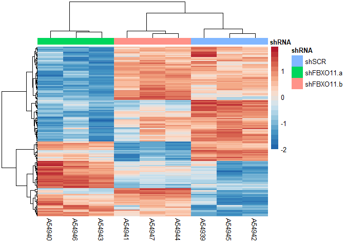

```r
library(RColorBrewer)

heatmap_pallete <- colorRampPalette(brewer.pal(8, name = "RdBu"))(21) %>% rev

anno.frame <- data.frame(sample = colnames(log.norm), shRNA = libs[match(colnames(log.norm), libs$library_name),]$treatment) %>%
  column_to_rownames(var = "sample")

anno.frame$shRNA <- factor(anno.frame$shRNA, levels = c("shSCR", "shFBXO11.a", "shFBXO11.b"))

as.matrix(log.norm) %>%
pheatmap(cluster_cols = T,
         cluster_rows = T,
         scale = "none",
         clustering_method = "ward.D2",
         clustering_distance_cols = "euclidean",
         show_rownames = F,
         annotation_col = anno.frame, color = heatmap_pallete)
```

> Conclusion: When considering all differentially expressed genes (union), shFBXO11.b (#10) is more similar to shSCR than shFBXO11.a (#9).

> Overall: Try Limma analysis to better estimate variance and to avoid losing statistical power when doing separate pairwise comparisons.

## Heatmap for differentially expressed genes in BOTH shFBXO11 constructs

```r
signif.genes <- intersect(genes_a, genes_b)

expr.signif <- expr[which(expr$Name %in% signif.genes),]

expr.signif2 <- column_to_rownames(expr.signif, var = "Name")
head(expr.signif2)
```

```
## # A tibble: 6 x 9
##   A54945 A54947 A54946 A54944 A54940 A54942 A54941 A54939 A54943
##    <dbl>  <dbl>  <dbl>  <dbl>  <dbl>  <dbl>  <dbl>  <dbl>  <dbl>
## 1  219.   324.   161.   305.   160.   229.   288.   217.   149.
## 2   93.5   22.6   32.9   19.1   28.7   84.5   21.8   95.8   27.7
## 3   50.7   93.7   26.9   94.9   23.9   49.3   89.9   50.6   25.0
## 4  112.   191.   207.   178.   201.   107.   164.   118.   181.
## 5 1217.   946.   795.   822.   701.  1162.   813.  1239.   716.
## 6   53.4   22.0   27.7   22.1   31.0   54.2   22.5   49.0   29.1
```

Log transform, and scale rows:

```r
# don't need to add a constant for the log scaling because all are >0
log.norm <- log2(expr.signif2) %>%
  t() %>% scale() %>% (t) %>% ## method from https://github.com/STAT540-UBC/STAT540-UBC.github.io/blob/master/seminars/seminars_winter_2019/seminar6/sm06_clustering-pca.md
  as.matrix()

log.norm <- na.omit(log.norm)
any(is.na(log.norm))
```

```
## [1] FALSE
```

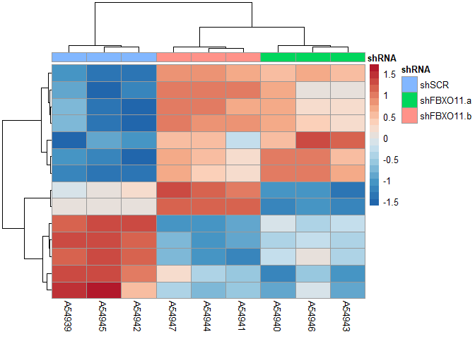

```r
anno.frame <- data.frame(sample = colnames(log.norm), shRNA = libs[match(colnames(log.norm), libs$library_name),]$treatment) %>%
  column_to_rownames(var = "sample")

anno.frame$shRNA <- factor(anno.frame$shRNA, levels = c("shSCR", "shFBXO11.a", "shFBXO11.b"))

as.matrix(log.norm) %>%
pheatmap(cluster_cols = T,
         cluster_rows = T,
         scale = "none",
         clustering_method = "ward.D2",
         clustering_distance_cols = "euclidean",
         show_rownames = F,
         annotation_col = anno.frame, color = heatmap_pallete)
```

> Conclusion: When considering the common DE genes (intersection), the two shFBXO11 treatments cluster distinctly from shSCR.

# Limma analysis

> Note: Limma analysis works well for low “n” experiments because it uses a moderated t-test to better estimate variance across genes.

> It IS possible to perform limma for 3 groups, then report results for each comparison (avoids losing power!)

Method from Limma User Guide section on RNA-seq: https://www.bioconductor.org/packages/devel/bioc/vignettes/limma/inst/doc/usersguide.pdf

```r
## Reload saved data
load("./FBXO11/expr.RData")
load("./FBXO11/libs.RData")



# Design factors
libs$treatment <- ifelse(test = grepl(pattern = "shSCR", x = libs$specimen_subset_external_id), yes = "ctrl", no =
                           ifelse(test = grepl(pattern = "shFBXO11#9", x = libs$specimen_subset_external_id), yes = "shFBXO11.a", no = "shFBXO11.b"))

design.table <- select(libs, library_name, treatment) %>%
  column_to_rownames(var = "library_name")
design.table$treatment <- factor(design.table$treatment, levels = c("ctrl", "shFBXO11.a", "shFBXO11.b"))


# make model matrix
model.matrix <- model.matrix(~treatment, data = design.table)

  ## commented out the stuff for the makeContrasts() method
  #x <- c("shSCR-shFBXO11.b")
  #contrast.matrix <- makeContrasts(contrasts = x, levels = design.table)



# convert expr to matrix
expr.matrix <- column_to_rownames(expr, var = "Name") %>%
  select(rownames(design.table)) %>% # put columns in same order as the design matrix
  as.matrix()
# filter to "highly expressed" genes
thresh <- expr.matrix >= 5
keep <- rowSums(thresh) >= 2 # keep rows where there are > 2 samples with tpm > 5

expr.matrix.keep <- expr.matrix[keep,]
```

## Normalizing & log transformation

```r
dge <- DGEList(counts = expr.matrix.keep)

dge <- calcNormFactors(dge) # From the Limma Userguide: It is usual to apply scale normalization to RNA-seq read counts, and the TMM normalization method [34] in particular has been found to perform well in comparative studies. This can be applied to the DGEList object

kable(head(dge$counts))
```

|  | A54939 | A54940 | A54941 | A54942 | A54943 | A54944 | A54945 | A54946 | A54947 |
| --- | --- | --- | --- | --- | --- | --- | --- | --- | --- |
| ENST00000494149 | 7.491241 | 3.406867 | 5.204649 | 6.812622 | 4.527275 | 5.917108 | 6.312374 | 6.817580 | 5.484473 |
| ENST00000623083 | 6.723140 | 7.166121 | 7.513370 | 6.213673 | 6.145557 | 7.718823 | 6.107802 | 6.883171 | 7.712641 |
| ENST00000599771 | 9.128803 | 9.273547 | 9.977130 | 14.545309 | 10.078416 | 14.117502 | 13.374769 | 13.281399 | 11.277027 |
| ENST00000416931 | 119.985967 | 165.840842 | 162.077902 | 116.268604 | 120.318414 | 94.180728 | 93.371523 | 61.124406 | 88.833200 |
| ENST00000457540 | 58.084029 | 64.861148 | 73.284931 | 70.872431 | 73.885293 | 67.842562 | 68.317703 | 60.415320 | 67.094112 |
| ENST00000617238 | 350.485344 | 286.532116 | 429.256664 | 433.241176 | 285.599971 | 320.779323 | 214.998546 | 175.050479 | 260.938612 |

```r
log.dge <- cpm(y = dge, normalized.lib.sizes = FALSE, log = TRUE, lib.size = NA) # using the cpm function to take the log2(count+0.01), BUT since the values are already in TPM, set all other paramters to FALSE or NA to avoid taking "per million" again.

kable(head(log.dge))
```

|  | A54939 | A54940 | A54941 | A54942 | A54943 | A54944 | A54945 | A54946 | A54947 |
| --- | --- | --- | --- | --- | --- | --- | --- | --- | --- |
| ENST00000494149 | 3.346942 | 2.535991 | 2.949503 | 3.242304 | 2.807192 | 3.088322 | 3.156834 | 3.249305 | 3.006281 |
| ENST00000623083 | 3.225240 | 3.297230 | 3.350365 | 3.140752 | 3.126579 | 3.384192 | 3.120890 | 3.260012 | 3.382246 |
| ENST00000599771 | 3.576493 | 3.595713 | 3.682512 | 4.151134 | 3.694735 | 4.114075 | 4.043951 | 4.043440 | 3.833244 |
| ENST00000416931 | 7.030420 | 7.491488 | 7.458156 | 6.988757 | 7.034518 | 6.691331 | 6.676832 | 6.090700 | 6.607535 |
| ENST00000457540 | 6.008802 | 6.163668 | 6.334243 | 6.290130 | 6.345793 | 6.229679 | 6.237169 | 6.074400 | 6.212878 |
| ENST00000617238 | 8.561241 | 8.273117 | 8.852303 | 8.868511 | 8.267918 | 8.438079 | 7.862875 | 7.578764 | 8.140970 |

```r
kable(head(log2(dge$counts))) ## these results are fairly similar, so I think that my method using cpm() worked
```

|  | A54939 | A54940 | A54941 | A54942 | A54943 | A54944 | A54945 | A54946 | A54947 |
| --- | --- | --- | --- | --- | --- | --- | --- | --- | --- |
| ENST00000494149 | 2.905205 | 1.768446 | 2.379801 | 2.768210 | 2.178643 | 2.564892 | 2.658183 | 2.769260 | 2.455353 |
| ENST00000623083 | 2.749135 | 2.841192 | 2.909460 | 2.635446 | 2.619544 | 2.948381 | 2.610653 | 2.783073 | 2.947225 |
| ENST00000599771 | 3.190426 | 3.213121 | 3.318625 | 3.862482 | 3.333197 | 3.819413 | 3.741442 | 3.731335 | 3.495315 |
| ENST00000416931 | 6.906722 | 7.373655 | 7.340544 | 6.861318 | 6.910714 | 6.557360 | 6.544911 | 5.933677 | 6.473027 |
| ENST00000457540 | 5.860070 | 6.019283 | 6.195445 | 6.147153 | 6.207215 | 6.084119 | 6.094188 | 5.916842 | 6.068114 |
| ENST00000617238 | 8.453210 | 8.162553 | 8.745697 | 8.759027 | 8.157852 | 8.325437 | 7.748183 | 7.451627 | 8.027567 |

## Perform limma-trend analysis

```r
fit <- lmFit(object = log.dge, design = model.matrix)  # fit with all groups to avoid losing power, but will need to extract results for each experimental group separately
fitEb <- eBayes(fit, trend=TRUE)

# results for shFBXO11.a vs. ctrl
top_a <- topTable(fitEb, coef = "treatmentshFBXO11.a", sort.by = "p", n = Inf) %>%
  rownames_to_column(var = "Transcript") %>%
  mutate(signif = adj.P.Val < 0.05 & abs(logFC) > 1)
head(top_a)
```

```
##        Transcript     logFC  AveExpr         t      P.Value    adj.P.Val
## 1 ENST00000371732 -2.518802 3.799988 -31.19699 7.430023e-10 1.371656e-05
## 2 ENST00000397406 -1.929505 4.281757 -24.62347 5.135360e-09 4.740194e-05
## 3 ENST00000366903  1.676875 3.347192  23.04834 8.797441e-09 4.839102e-05
## 4 ENST00000319340 -1.479387 4.580358 -22.55638 1.048503e-08 4.839102e-05
## 5 ENST00000290705 -2.279134 3.713746 -20.62284 2.170724e-08 8.014746e-05
## 6 ENST00000221418 -2.043354 7.190231 -19.21486 3.848571e-08 1.184141e-04
##           B signif
## 1 11.699699   TRUE
## 2 10.562692   TRUE
## 3 10.201842   TRUE
## 4 10.080175   TRUE
## 5  9.555117   TRUE
## 6  9.119514   TRUE
```

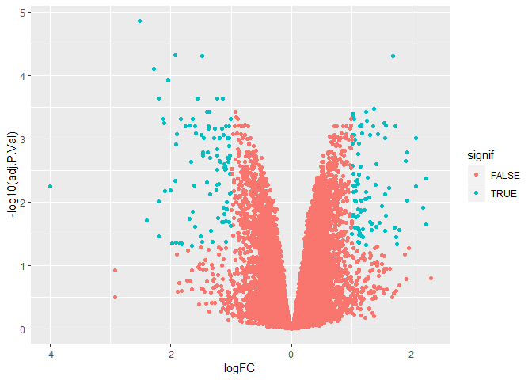

```r
ggplot(top_a, aes(logFC, -log10(adj.P.Val))) +
  geom_point(aes(color = signif))
```

```r
write.csv(x = top_a, file = "./FBXO11/Limma/Limma_result_shFBXO11-9_vs_shSCR.csv", row.names = F)

# results for shFBXO11.b vs. ctrl
top_b <- topTable(fitEb, coef = "treatmentshFBXO11.b", sort.by = "p", n = Inf) %>%
  rownames_to_column(var = "Transcript") %>%
  mutate(signif = adj.P.Val < 0.05 & abs(logFC) > 1)
head(top_b)
```

```
##        Transcript     logFC  AveExpr         t      P.Value    adj.P.Val
## 1 ENST00000265643 -2.007431 5.456055 -21.48200 1.558758e-08 0.0001940629
## 2 ENST00000286713 -1.415996 3.725568 -20.33441 2.433265e-08 0.0001940629
## 3 ENST00000620913 -1.399649 4.792965 -19.69369 3.153614e-08 0.0001940629
## 4 ENST00000344843 -1.436316 7.506916 -18.29384 5.723279e-08 0.0002156084
## 5 ENST00000310624 -1.237790 4.349835 -18.24830 5.839564e-08 0.0002156084
## 6 ENST00000347703 -1.161754 5.208797 -17.62316 7.734843e-08 0.0002296508
##          B signif
## 1 9.646958   TRUE
## 2 9.333499   TRUE
## 3 9.145296   TRUE
## 4 8.697408   TRUE
## 5 8.681928   TRUE
## 6 8.463200   TRUE
```

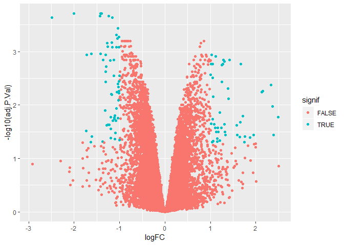

```r
ggplot(top_b, aes(logFC, -log10(adj.P.Val))) +
  geom_point(aes(color = signif))
```

```r
write.csv(x = top_b, file = "./FBXO11/Limma/Limma_result_shFBXO11-10_vs_shSCR.csv", row.names = F)

# List of genes with significant adj.P.Val in both shFBXO11 treatments
common_genes <- intersect(top_a[which(top_a$adj.P.Val < 0.05),]$Transcript, top_b[which(top_b$adj.P.Val < 0.05),]$Transcript)

# Summaries
nrow(top_a[which(top_a$adj.P.Val < 0.05),])
```

```
## [1] 2049
```

```r
nrow(top_b[which(top_b$adj.P.Val < 0.05),])
```

```
## [1] 1856
```

```r
length(common_genes)
```

```
## [1] 543
```

### QC Check: p-values histograms

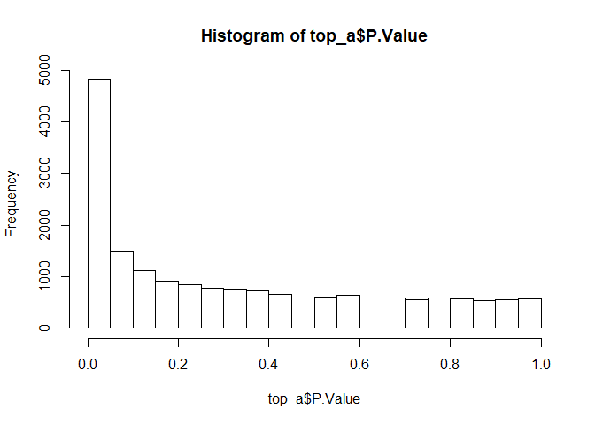

```r
hist(top_a$P.Value)
```

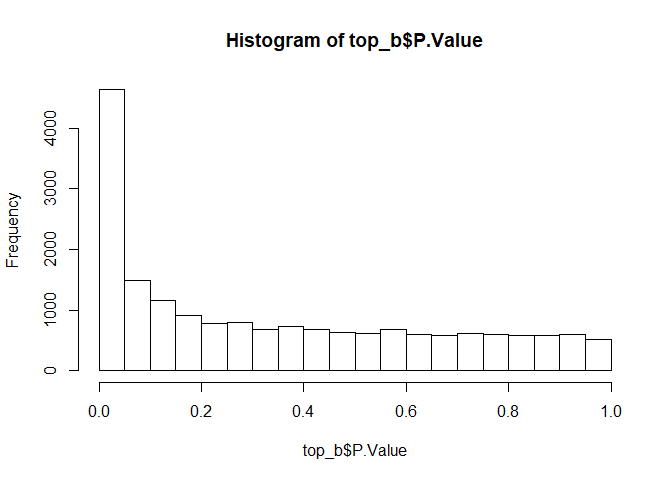

```r
hist(top_b$P.Value)
```

### Identify the ~500 genes that are significantly altered in both shFBXO11 treatments

```r
signif.genes <- common_genes
```

## Heatmap for differentially expressed genes in BOTH shFBXO11 constructs

```r
expr.signif <- expr[which(expr$Name %in% signif.genes),]

expr.signif2 <- column_to_rownames(expr.signif, var = "Name")
head(expr.signif2)
```

```
## # A tibble: 6 x 9
##   A54945 A54947 A54946 A54944 A54940 A54942 A54941 A54939 A54943
##    <dbl>  <dbl>  <dbl>  <dbl>  <dbl>  <dbl>  <dbl>  <dbl>  <dbl>
## 1  14.6   20.7   22.8   23.8   25.7   13.3   19.4   17.7   23.2
## 2   7.47   3.20   4.82   2.93   5.02   6.99   3.70  11.1    4.33
## 3   7.14   5.23   3.89   3.68   3.60   8.86   3.48   6.17   2.99
## 4  36.0   54.6   27.1   62.6   18.1   34.6   57.2   38.1   26.9
## 5   8.97   4.90   5.71   4.89   3.44   7.78   4.50   9.12   3.13
## 6  64.0   54.9   53.6   52.5   54.2   66.5   49.8   66.5   49.9
```

Log transform, and scale rows:

```r
# don't need to add a constant for the log scaling because all are >0
log.norm <- log2(expr.signif2) %>%
  t() %>% scale() %>% (t) %>% ## method from https://github.com/STAT540-UBC/STAT540-UBC.github.io/blob/master/seminars/seminars_winter_2019/seminar6/sm06_clustering-pca.md
  as.matrix()

log.norm <- na.omit(log.norm)
any(is.na(log.norm))
```

```
## [1] FALSE
```

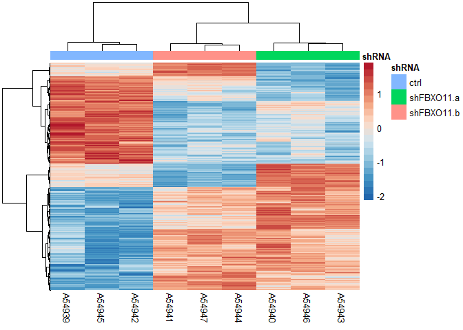

```r
anno.frame <- data.frame(sample = colnames(log.norm), shRNA = libs[match(colnames(log.norm), libs$library_name),]$treatment) %>%
  column_to_rownames(var = "sample")

anno.frame$shRNA <- factor(anno.frame$shRNA, levels = c("ctrl", "shFBXO11.a", "shFBXO11.b"))

heatmap_pallete <- colorRampPalette(brewer.pal(8, name = "RdBu"))(21) %>% rev

out <- as.matrix(log.norm) %>%
pheatmap(cluster_cols = T,
         cluster_rows = T,
         scale = "none",
         clustering_method = "ward.D2",
         clustering_distance_cols = "euclidean",
         show_rownames = F,
         annotation_col = anno.frame, color = heatmap_pallete)
```

> Conclusion: Compared to DEseq, Limma analysis identified more differentially expressed genes that correspond between the 2 shFBXO11 construct treatments.

> Next step: Extract the row clusters from this heatmap to get genes that are down in both or up in both shFBXO11 construct treatments.

### Extract row clusters

```r
anno.rowclusters <- cutree(out$tree_row, k = 4) %>% as.data.frame()
colnames(anno.rowclusters) <- "cluster"

anno.rowclusters$cluster <- factor(anno.rowclusters$cluster)
levels(anno.rowclusters$cluster) <- c("D", "B", "A", "C")
anno.rowclusters$cluster <- factor(anno.rowclusters$cluster, levels = c("A", "B", "C", "D")) # to give them a logical order in the heatmap
```

## Heatmap with row clusters

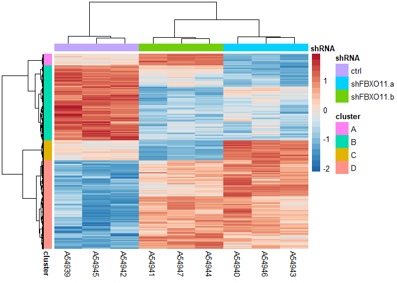

```r
as.matrix(log.norm) %>%
pheatmap(cluster_cols = T,
         cluster_rows = T,
         scale = "none",
         clustering_method = "ward.D2",
         clustering_distance_cols = "euclidean",
         show_rownames = F,
         annotation_col = anno.frame,
         color = heatmap_pallete,
         annotation_row = anno.rowclusters)
```

### Clusters of interest: extract expression data in limma result for each shFBXO11 construct

Interested in transcript clusters B (downreg in shFBXO11’s) and D (upreg in shFBXO11’s)

```r
anno.cl2 <- rownames_to_column(anno.rowclusters, var = "Transcript")

top_a_clust <- left_join(top_a, anno.cl2) %>%
  na.omit() %>%
  filter(cluster %in% c("B", "D"))
write.csv(x = top_a_clust, file = "./FBXO11/Limma/Limma_commonEffectClusters_shFBXO11-9_vs_shSCR.csv", row.names = F)

top_b_clust <- left_join(top_b, anno.cl2) %>%
  na.omit() %>%
  filter(cluster %in% c("B", "D"))
write.csv(x = top_b_clust, file = "./FBXO11/Limma/Limma_commonEffectClusters_shFBXO11-10_vs_shSCR.csv", row.names = F)
```